# Harmonize: physique

This report lists the candidate variable for DataScheme variables of the construct **physique**.

# (I) Exposition

> This report is a record of interaction with a data transfer object (dto) produced by `./manipulation/0-ellis-island.R`.

The next section recaps this script, exposes the architecture of the DTO, and demonstrates the language of interacting with it.

## (I.A) Ellis Island

> All data land on Ellis Island.

The script `0-ellis-island.R` is the first script in the analytic workflow. It accomplished the following:

- 1. Reads in raw data files from the candidate studies
- 2. Extract, combines, and exports their metadata (specifically, variable names and labels, if provided) into `./data/shared/derived/meta-data-live.csv`, which is updated every time Ellis Island script is executed.
- 3. Augments raw metadata with instructions for renaming and classifying variables. The instructions are provided as manually entered values in `./data/shared/meta-data-map.csv`. They are used by automatic scripts in later harmonization and analysis.
- 4. Combines unit and metadata into a single DTO to serve as a starting point to all subsequent analyses.

```r
# load the product of 0-ellis-island.R,  a list object containing data and metadata
dto <- readRDS("./data/unshared/derived/dto.rds")
```

```r
# the list is composed of the following elements
names(dto)
```

```
[1] "studyName" "filePath"  "unitData"  "metaData"
```

```r
# 1st element - names of the studies as character vector
dto[["studyName"]]
```

```
[1] "alsa"  "lbsl"  "satsa" "share" "tilda"
```

```r
# 2nd element - file paths of the data files for each study as character vector
dto[["filePath"]]
```

```
[1] "./data/unshared/raw/ALSA-Wave1.Final.sav"         "./data/unshared/raw/LBSL-Panel2-Wave1.Final.sav"
[3] "./data/unshared/raw/SATSA-Q3.Final.sav"           "./data/unshared/raw/SHARE-Israel-Wave1.Final.sav"
[5] "./data/unshared/raw/TILDA-Wave1.Final.sav"
```

```r
# 3rd element - is a list object containing the following elements
names(dto[["unitData"]])
```

```
[1] "alsa"  "lbsl"  "satsa" "share" "tilda"
```

```r
# each of these elements is a raw data set of a corresponding study, for example
dplyr::tbl_df(dto[["unitData"]][["lbsl"]])
```

```
Source: local data frame [656 x 38]

        id AGE94 SEX94  MSTAT94 EDUC94     NOWRK94  SMK94                                         SMOKE
     (int) (int) (int)   (fctr)  (int)      (fctr) (fctr)                                        (fctr)
1  4001026    68     1 divorced     16 no, retired     no                                  never smoked
2  4012015    94     2  widowed     12 no, retired     no                                  never smoked
3  4012032    94     2  widowed     20 no, retired     no don't smoke at present but smoked in the past
4  4022004    93     2       NA     NA          NA     NA                                  never smoked
5  4022026    93     2  widowed     12 no, retired     no                                  never smoked
6  4031031    92     1  married      8 no, retired     no don't smoke at present but smoked in the past
7  4031035    92     1  widowed     13 no, retired     no don't smoke at present but smoked in the past
8  4032201    92     2       NA     NA          NA     NA don't smoke at present but smoked in the past
9  4041062    91     1  widowed      7          NA     no don't smoke at present but smoked in the past
10 4042057    91     2       NA     NA          NA     NA                                            NA
..     ...   ...   ...      ...    ...         ...    ...                                           ...
Variables not shown: ALCOHOL (fctr), WINE (int), BEER (int), HARDLIQ (int), SPORT94 (int), FIT94 (int), WALK94 (int),
  SPEC94 (int), DANCE94 (int), CHORE94 (int), EXCERTOT (int), EXCERWK (int), HEIGHT94 (int), WEIGHT94 (int), HWEIGHT
  (int), HHEIGHT (int), SRHEALTH (fctr), smoke_now (lgl), smoked_ever (lgl), year_of_wave (dbl), age_in_years (dbl),
  year_born (dbl), female (lgl), marital (chr), single (lgl), educ3 (chr), current_work_2 (lgl), current_drink (lgl),
  sedentary (lgl), poor_health (lgl)
```

### Meta

```r
# 4th element - a dataset names and labels of raw variables + added metadata for all studies
dto[["metaData"]] %>% dplyr::select(study_name, name, item, construct, type, categories, label_short, label) %>%
  DT::datatable(
    class   = 'cell-border stripe',
    caption = "This is the primary metadata file. Edit at `./data/shared/meta-data-map.csv",
    filter  = "top",
    options = list(pageLength = 6, autoWidth = TRUE)
  )
```

|  | study_name | name | item | construct | type | categories | label_short | label |
| --- | --- | --- | --- | --- | --- | --- | --- | --- |
| 1 | alsa | SEQNUM | id | id | demo | 2087 | Sequence Number | Sequence Number |
| 2 | alsa | EXRTHOUS |  | physact | activity |  | Exertion around house | Exertion around house |
| 3 | alsa | HWMNWK2W |  | physact | activity |  | Times walked in past two weeks | Times walked in past two weeks |
| 4 | alsa | LSVEXC2W |  | physact | activity |  | Less vigor sessions last 2 weeks | Less vigor sessions last 2 weeks |
| 5 | alsa | LSVIGEXC |  | physact | activity |  | Less vigor past 2 weeks | Less vigor past 2 weeks |
| 6 | alsa | TMHVYEXR |  | physact | activity |  | Time heavy physical exertion | Time heavy physical exertion |
| 7 | alsa | TMVEXC2W |  | physact | activity |  | Vigor Time past 2 weeks | Vigor Time past 2 weeks |
| 8 | alsa | VIGEXC2W |  | physact | activity |  | Vigor Sessions in past 2 weeks | Vigor Sessions in past 2 weeks |
| 9 | alsa | VIGEXCS |  | physact | activity |  | Vigorous exercise | Vigorous exercise |
| 10 | alsa | WALK2WKS |  | physact | activity |  | Walking past 2 weeks | Walking past 2 weeks |

[output cut: 140 more lines]

## (I.B) Target-H

> Everybody wants to be somebody.

We query metadata set to retrieve all variables potentially tapping the construct `physique`. These are the candidates to enter the DataSchema and contribute to computing harmonized variables.

*NOTE*: what is being retrieved depends on the manually entered values in the column `construct` of the metadata file `./data/shared/meta-data-map.csv`. To specify a different group of variables, edit the metadata, not the script.

```r
meta_data <- dto[["metaData"]] %>%
  dplyr::filter(construct %in% c('physique')) %>%
  dplyr::select(study_name, name, construct, label_short, categories, url) %>%
  dplyr::arrange(construct, study_name)
knitr::kable(meta_data)
```

| study_name | name | construct | label_short | categories | url |
| --- | --- | --- | --- | --- | --- |
| alsa | WEIGHT | physique | Weight in kilograms | NA |  |
| lbsl | HEIGHT94 | physique | Height in Inches | NA |  |
| lbsl | WEIGHT94 | physique | Weight in Pounds | NA |  |
| lbsl | HWEIGHT | physique | Self-reported weight in pounds | NA |  |
| lbsl | HHEIGHT | physique | Self-reported height in inches | NA |  |
| satsa | GHTCM | physique |  | NA |  |
| satsa | GWTKG | physique |  | NA |  |
| satsa | GPI | physique |  | NA |  |
| share | PH0130 | physique | how tall are you? | NA |  |
| share | PH0120 | physique | weight of respondent | NA |  |
| tilda | SR.HEIGHT.CENTIMETRES | physique | Height Centimetres | NA |  |
| tilda | HEIGHT | physique | Respondent height | NA |  |
| tilda | SR.WEIGHT.KILOGRAMMES | physique | Weight Kilogrammes | NA |  |
| tilda | WEIGHT | physique | Respondent weight | NA |  |

View [descriptives : physique](https://rawgit.com/IALSA/ialsa-2016-groningen-public/master/describe-physique.html) for closer examination of each candidate.

After reviewing descriptives and relevant codebooks, the following operationalization of the harmonized variables for `physique` have been adopted:

#### Target (1) : `bmi`

from metric:

```r
bmi = weight_kg / height_m ^ 2
```

from imperial

```r
bmi = weight_lb * 703 / height_in ^ 2
```

These variables will be generated next, in the Development section.

# (II) Development

The particulare goal of this section is to ensure that the schema to encode the values for the `physique` variable is consisten across studies.

In this section we will define the schema sets for harmonizing `physique` construct (i.e. specify which variables from which studies will be contributing to computing harmonized variables ). Each of these schema sets will have a particular pattern of possible response values to these variables, which we will export for inspection as `.csv` tables. We then will manually edit these `.csv` tables, populating new columns that will map values of harmonized variables to the specific response pattern of the schema set variables. We then will import harmonization algorithms encoded in `.csv` tables and apply them to compute harmonized variables in the dataset combining raw and harmonized variables for `physique` construct across studies.

## (II.B) `bmi`

from metric:

```r
bmi = weight_kg / height_m ^ 2
```

from imperial

```r
bmi = weight_lb * 703 / height_in ^ 2
```

### ALSA

Items that can contribute to generating values for the harmonized variable `bmi` are:

```r
dto[["metaData"]] %>%
  dplyr::filter(study_name=="alsa", construct %in% c("physique")) %>%
  dplyr::select(study_name, name, label,categories)
```

```
  study_name   name               label categories
1       alsa WEIGHT Weight in kilograms         NA
```

ALSA is lacking the measure of height. It is not possible to calculate `bmi` for this study.

```r
dto[["unitData"]][["alsa"]] <- dto[["unitData"]][["alsa"]] %>%
    dplyr::mutate(
      HIEGHT = NA,
      bmi = (WEIGHT)/ (HIEGHT^2))
# verify
dto[["unitData"]][["alsa"]] %>%
  dplyr::filter(id %in% sample(unique(id),10)) %>%
  dplyr::select_("id", "WEIGHT","HIEGHT", "bmi")
```

```
      id WEIGHT HIEGHT bmi
1   3822   57.3     NA  NA
2   5691   60.5     NA  NA
3   9152   63.6     NA  NA
4  12981   70.0     NA  NA
5  24731   60.0     NA  NA
6  27021   84.0     NA  NA
7  28092   75.5     NA  NA
8  28501   76.4     NA  NA
9  35731     NA     NA  NA
10 40762   65.9     NA  NA
```

### LBSL

Items that can contribute to generating values for the harmonized variable `bmi` are:

```r
dto[["metaData"]] %>%
  dplyr::filter(study_name == "lbsl", construct == "physique") %>%
  dplyr::select(study_name, name, label_short,categories)
```

```
  study_name     name                    label_short categories
1       lbsl HEIGHT94               Height in Inches         NA
2       lbsl WEIGHT94               Weight in Pounds         NA
3       lbsl  HWEIGHT Self-reported weight in pounds         NA
4       lbsl  HHEIGHT Self-reported height in inches         NA
```

We compute `bmi` according to the declared formula:

```r
dto[["unitData"]][["lbsl"]] <- dto[["unitData"]][["lbsl"]] %>%
  dplyr::mutate(bmi = (WEIGHT94 * 703)/ (HEIGHT94^2))
# verify
dto[["unitData"]][["lbsl"]] %>%
  dplyr::filter(id %in% sample(unique(id),10)) %>%
  dplyr::select_("id", "WEIGHT94","HEIGHT94", "bmi")
```

```
        id WEIGHT94 HEIGHT94      bmi
1  4102156      150       60 29.29167
2  4131061       NA       NA       NA
3  4152078      160       61 30.22843
4  4191085      165       64 28.31909
5  4192096       NA       NA       NA
6  4282018       NA       62       NA
7  4312076      110       58 22.98751
8  4391047       NA       NA       NA
9  4411036      315       70 45.19286
10 4432039       NA       NA       NA
```

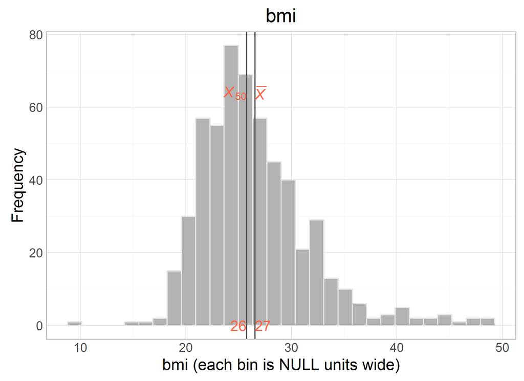

```r
# graph
histogram_continuous(dto[["unitData"]][["lbsl"]],"bmi")
```

### SATSA

Items that can contribute to generating values for the harmonized variable `bmi` are:

```r
dto[["metaData"]] %>%
  dplyr::filter(study_name == "satsa", construct == "physique") %>%
  dplyr::select(study_name, name, label_short,categories)
```

```
  study_name  name label_short categories
1      satsa GHTCM                     NA
2      satsa GWTKG                     NA
3      satsa   GPI                     NA
```

We compute `bmi` according to the declared formula:

```r
dto[["unitData"]][["satsa"]] <- dto[["unitData"]][["satsa"]] %>%
  dplyr::mutate(bmi = (GWTKG)/ ((GHTCM/100)^2))
# verify
dto[["unitData"]][["satsa"]] %>%
  dplyr::filter(id %in% sample(unique(id),10)) %>%
  dplyr::select_("id", "GWTKG","GHTCM","GPI", "bmi")
```

```
        id GWTKG GHTCM      GPI      bmi
1   132821    49   153 20.92969 20.93212
2   133131    54   154 22.76562 22.76944
3   169822    76   182 22.94141 22.94409
4   177212    70   177 22.33984 22.34352
5   179861    95   175 31.01953 31.02041
6   191801    64   157 25.96094 25.96454
7  2105661    75   170 25.94922 25.95156
8  2115422    53   158 21.23047 21.23057
9  2388481    65   164 24.16406 24.16716
10 2393821    60   181 18.31250 18.31446
```

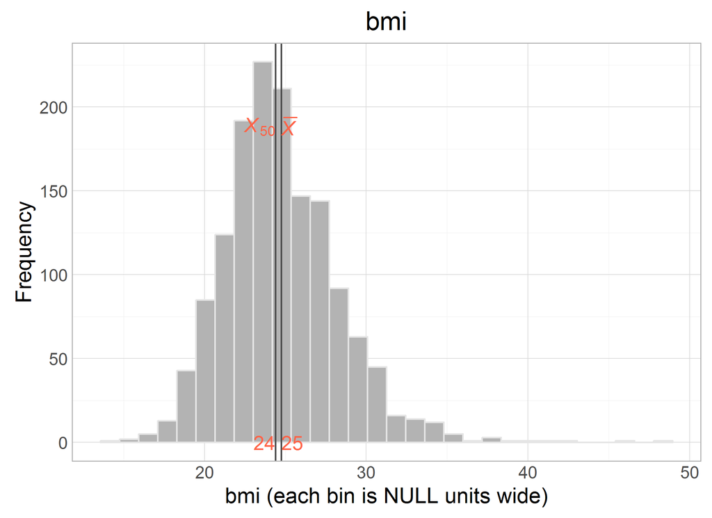

```r
# graph
histogram_continuous(dto[["unitData"]][["satsa"]],"bmi")
```

### SHARE

Items that can contribute to generating values for the harmonized variable `bmi` are:

```r
dto[["metaData"]] %>%
  dplyr::filter(study_name == "share", construct == "physique") %>%
  dplyr::select(study_name, name, label_short,categories)
```

```
  study_name   name          label_short categories
1      share PH0130    how tall are you?         NA
2      share PH0120 weight of respondent         NA
```

We compute `bmi` according to the declared formula:

```r
# recode non-numeric flags
ds <- dto[["unitData"]][["share"]]
str(ds$PH0130); summary(ds$PH0130); table(ds$PH0130)
```

```
Classes 'labelled', 'numeric'  atomic [1:2598] 182 160 164 165 173 168 165 154 165 175 ...
  ..- attr(*, "value.labels")= Named num [1:2] 1e+07 1e+07
  .. ..- attr(*, "names")= chr [1:2] "don't know" "refusal"
  ..- attr(*, "label")= Named chr "how tall are you?"
  .. ..- attr(*, "names")= chr "PH0130"
```

```
    Min.  1st Qu.   Median     Mean  3rd Qu.     Max.     NA's
     140      160      167   196800      172 10000000        4
```

```
    140     143     145     146     147     148     149     150     151     152     153     154     155     156     157
      2       1       9       1       5       6       1      64       5      29      17      26      70      50      45
    158     159     160     161     162     163     164     165     166     167     168     169     170     171     172
     94      20     245      22     106      80     101     246      44     109     137      38     249      23     109
    173     174     175     176     177     178     179     180     181     182     183     184     185     186     187
     62      65     111      59      20      60      17      65      12      27      22       6      26      12      10
    188     190     191     192     194     198     204 9999998 9999999
      2       4       3       3       1       1       1       1      50
```

```r
ds$PH0130 <- as.numeric(ds$PH0130)
ds$PH0130 <- car::recode(ds$PH0130, "
            c(9999998,9999999) = NA
            ")
str(ds$PH0120); summary(ds$PH0120); table(ds$PH0120)
```

```
Classes 'labelled', 'numeric'  atomic [1:2598] 110 100 110 100 75 64 90 58 83 94 ...
  ..- attr(*, "value.labels")= Named num [1:2] 1e+07 1e+07
  .. ..- attr(*, "names")= chr [1:2] "don't know" "refusal"
  ..- attr(*, "label")= Named chr "weight of respondent"
  .. ..- attr(*, "names")= chr "PH0120"
```

```
   Min. 1st Qu.  Median    Mean 3rd Qu.    Max.    NA's
      0      65      74   18190      83 1000000       4
```

```
      0      10      32      41      42      43      44      45      46      47      48      49      50      51      52
      2       1       1       1       3       3       2       1       1       1       4       5      32      10      23
     53      54      55      56      57      58      59      60      61      62      63      64      65      66      67
     32      29      43      21      31      48      26     106      28      53      61      60     131      31      55
     68      69      70      71      72      73      74      75      76      77      78      79      80      81      82
     68      19     185      23      86      63      70     156      37      36      82      24     149      12      60
     83      84      85      86      87      88      89      90      91      92      93      94      95      96      97
     41      42     102      21      28      30      13      95       2      23      17      11      42      16       9
     98      99     100     101     102     103     104     105     106     107     108     109     110     112     114
     17       2      47       1       5       2       1      14       1       1       4       1      14       2       2
    115     117     118     120     125     128     130     135     140     146     150 1000000
      5       1       2       8       2       1       3       1       1       1       1      47
```

```r
ds$PH0120 <- car::recode(ds$PH0120, "
            c(0,10, 1000000) = NA
            ")
ds <- ds %>%
  dplyr::mutate(bmi = (PH0120)/ ((PH0130/100)^2))
dto[["unitData"]][["share"]] <- ds
# verify
dto[["unitData"]][["share"]] %>%
  dplyr::filter(id %in% sample(unique(id),10)) %>%
  dplyr::select_("id", "PH0120" ,"PH0130", "bmi")
```

```
             id PH0120 PH0130      bmi
1  2.505214e+12     74    164 27.51338
2  2.505221e+12     71    170 24.56747
3  2.505238e+12     66    162 25.14861
4  2.505240e+12    118    179 36.82781
5  2.505246e+12     50    155 20.81165
6  2.505247e+12     65    156 26.70940
7  2.505248e+12     81    165 29.75207
8  2.505282e+12     84    160 32.81250
9  2.505297e+12    100    177 31.91931
10 2.705288e+12     68    156 27.94214
```

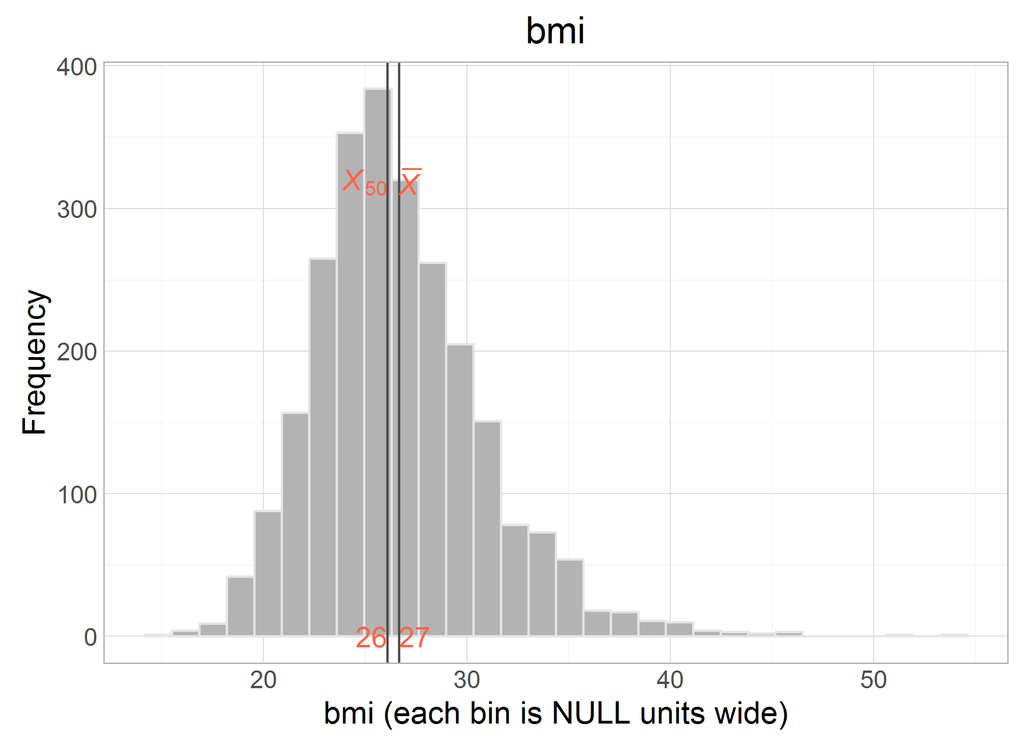

```r
# graph
histogram_continuous(dto[["unitData"]][["share"]],"bmi")
```

### TILDA

Items that can contribute to generating values for the harmonized variable `bmi` are:

```r
dto[["metaData"]] %>%
  dplyr::filter(study_name == "tilda", construct == "physique") %>%
  dplyr::select(study_name, name, label_short,categories)
```

```
  study_name                  name        label_short categories
1      tilda SR.HEIGHT.CENTIMETRES Height Centimetres         NA
2      tilda                HEIGHT  Respondent height         NA
3      tilda SR.WEIGHT.KILOGRAMMES Weight Kilogrammes         NA
4      tilda                WEIGHT  Respondent weight         NA
```

We compute `bmi` according to the declared formula:

```r
ds <- dto[["unitData"]][["tilda"]]
ds <- ds %>%
  dplyr::mutate(
    weight = ifelse(
    !is.na(WEIGHT), WEIGHT, ifelse(
      !is.na(SR.WEIGHT.KILOGRAMMES),SR.WEIGHT.KILOGRAMMES, NA)),
    height = ifelse(
      !is.na(HEIGHT), HEIGHT, ifelse(
        !is.na(SR.HEIGHT.CENTIMETRES),SR.HEIGHT.CENTIMETRES, NA))
  )
ds <- ds %>%
  dplyr::mutate(bmi = (weight)/ ((height/100)^2))
dto[["unitData"]][["tilda"]] <- ds
# verify
dto[["unitData"]][["tilda"]] %>%
  dplyr::filter(id %in% sample(unique(id),10)) %>%
  dplyr::select_("id","weight", "height", "bmi")
```

```
                   id weight height      bmi
1  85091               67.95  156.4 27.77896
2  174651                 NA     NA       NA
3  269051              51.50  156.8 20.94668
4  341091              62.50  150.6 27.55688
5  355731              88.20  185.0 25.77063
6  390411                 NA     NA       NA
7  400051              59.40  149.2 26.68387
8  446412              61.90  148.7 27.99424
9  484361              73.20  172.9 24.48618
10 532501              63.80  158.8 25.29995
```

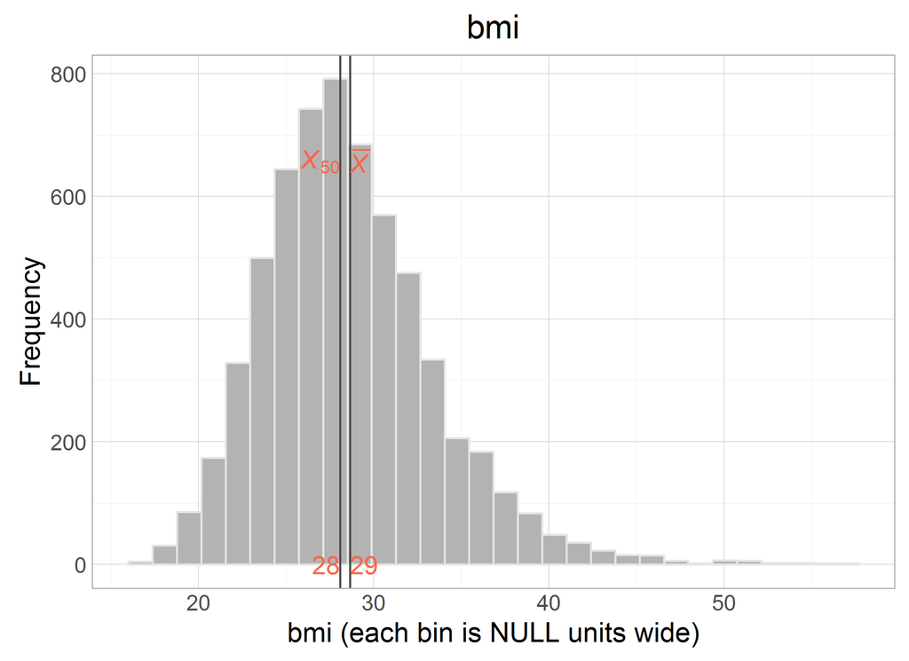

```r
# graph
histogram_continuous(dto[["unitData"]][["tilda"]],"bmi")
```

# (III) Recapitulation

At this point the `dto[["unitData"]]` elements (raw data files for each study) have been augmented with the harmonized variable `bmi`.

```r
dumlist <- list()
for(s in dto[["studyName"]]){
  ds <- dto[["unitData"]][[s]]
  dumlist[[s]] <- ds[,c("id","bmi")]
}
ds <- plyr::ldply(dumlist,data.frame,.id = "study_name")
head(ds)
```

```
  study_name  id bmi
1       alsa  41  NA
2       alsa  42  NA
3       alsa  61  NA
4       alsa  71  NA
5       alsa  91  NA
6       alsa 121  NA
```

```r
ds$id <- 1:nrow(ds) # some ids values might be identical, replace
for(s in dto[["studyName"]]){
  print(s)
  print(summary(dto[["unitData"]][[s]]$bmi))
}
```

```
[1] "alsa"
   Min. 1st Qu.  Median    Mean 3rd Qu.    Max.    NA's
     NA      NA      NA     NaN      NA      NA    2087
[1] "lbsl"
   Min. 1st Qu.  Median    Mean 3rd Qu.    Max.    NA's
  9.683  23.050  25.740  26.540  29.210  48.820     105
[1] "satsa"
   Min. 1st Qu.  Median    Mean 3rd Qu.    Max.    NA's
  14.70   22.45   24.39   24.75   26.78   48.90      46
[1] "share"
   Min. 1st Qu.  Median    Mean 3rd Qu.    Max.    NA's
  14.69   23.88   26.09   26.67   29.00   53.78      82
[1] "tilda"
   Min. 1st Qu.  Median    Mean 3rd Qu.    Max.    NA's
  16.46   25.23   28.09   28.64   31.36   56.77    2372
```

Finally, we have added the newly created, harmonized variables to the raw source objects and save the data transfer object.

```r
# Save as a compress, binary R dataset.  It's no longer readable with a text editor, but it saves metadata (eg, factor information).
saveRDS(dto, file="./data/unshared/derived/dto.rds", compress="xz")
```